# Text Analysis

```r
library(dplyr)
library(ggplot2)
library(readr)
library(stringi)
library(tidyr)
library(magrittr)

theme_set(theme_minimal())
```

This RMarkdown script is a revised and condensed version of tenth chapter from the book “Humanities Data in R”. There have been many changes over the past 5 year in regards to NLP technology and this revision uses our new R package (cleanNLP) in place of the older and unsupported coreNLP. The book itself is still useful as it contains additional information about each of the NLP tasks. We suggest pairing the exposition in the book but to run the R code from this file instead.

## # Introduction

In the previous chapter we explored methods for converting raw textual data into a sequence of tokens and associating these tokens with various metadata and relationships. The parsed information has already been shown to be effective in the retrieval of factual information (ex. character names) and a high-level categorization of narrative arcs and textual style. We continue with this approach by presenting several techniques for utilizing the output of NLP annotations to explore and visualize a corpus of textual documents.

# Term Frequency - Inverse Document Frequency

```r
library(cleanNLP)

cnlp_init_spacy()

text_names <- dir("data/wiki/", full.names=TRUE)
text_names_short <- stri_sub(text_names, 12, -5)
texts <- sapply(text_names, function(v) paste(readLines(v), collapse="\n"), USE.NAMES = FALSE)
anno <- cnlp_annotate(texts)
```

[output not shown]

[output cut: 124 more lines]

[output not shown]

```r
token <- anno$token
```

```r
token %>%
  filter(upos == "NOUN") %>%
  count(lemma, sort=TRUE)
```

```
## # A tibble: 13,102 x 2
##    lemma          n
##  * <chr>      <int>
##  1 work        2619
##  2 time        1733
##  3 philosophy  1618
##  4 year        1541
##  5 life        1475
##  6 theory      1475
##  7 book        1315
##  8 idea        1201
##  9 world       1138
## 10 man          876
## # … with 13,092 more rows
```

Constructing a term frequency matrix is quite easy because there is a special function in cleanNLP to create it:

```r
tf <- token %>%
  filter(upos == "NOUN") %>%
  cnlp_utils_tf()
rownames(tf) <- text_names_short
dim(tf)
```

```
## [1]   179 10000
```

The output reveals, for example, that Machiavelli’s page has $29$ lemmas equal to ‘work’ whereas Francis Bacon does not have a single reference to the lemma ‘theory’.

```r
tf[1:10,seq(1,45,by=5)]
```

```
## 10 x 9 sparse Matrix of class "dgCMatrix"
##                                  work philosophy theory man death state
## 16th_Acyutananda                    1          6      1   .     .     1
## 16th_Giordano_Bruno                16          9      5   2     8     1
## 16th_Jean_Bodin                    26          6     24   2     6    14
## 16th_Niccolò_Machiavelli           29          7      3   9     2    11
## 17th_Algernon_Sidney                2          .      1   2     8     .
## 17th_Baruch_Spinoza                14         21      .   8     7     3
## 17th_Blaise_Pascal                 20          6      9   6     9     2
## 17th_Elisabeth_of_the_Palatinate    2          5      2   1     3     .
## 17th_Francis_Bacon                  7          4      .   7     7     5
## 17th_Gottfried_Wilhelm_Leibniz     17         22     18   1     7     5
##                                  people point concept
## 16th_Acyutananda                      3     .       5
## 16th_Giordano_Bruno                   .     2       .
## 16th_Jean_Bodin                       4     4       6
## 16th_Niccolò_Machiavelli              9     3       1
## 17th_Algernon_Sidney                  1     .       .
## 17th_Baruch_Spinoza                   5     1       7
## 17th_Blaise_Pascal                    2     4       1
## 17th_Elisabeth_of_the_Palatinate      9     .       .
## 17th_Francis_Bacon                    1     .       .
## 17th_Gottfried_Wilhelm_Leibniz        4     4       8
```

Similarly, we can create a TF-IDF matrix with the function `cnlp_utils_tfidf`:

```r
tfidf <- token %>%
  filter(upos == "NOUN") %>%
  cnlp_utils_tfidf()
rownames(tfidf) <- text_names_short
dim(tfidf)
```

```
## [1]  179 1153
```

Now that we have our importance score, let’s look at the first ten philosophers.

```r
tfidf[1:10,seq(1,45,by=5)]
```

```
## 10 x 9 sparse Matrix of class "dgCMatrix"
##                                       idea    family   history     order
## 16th_Acyutananda                 0.1528989 0.2646473 .         .
## 16th_Giordano_Bruno              0.9173934 .         0.6078134 0.6478889
## 16th_Jean_Bodin                  2.1405846 0.2646473 3.3429736 .
## 16th_Niccolò_Machiavelli         1.8347868 1.0585890 1.5195334 1.9436666
## 17th_Algernon_Sidney             0.1528989 0.2646473 .         .
## 17th_Baruch_Spinoza              1.6818879 1.5878835 0.3039067 1.6197222
## 17th_Blaise_Pascal               0.1528989 0.7939418 .         0.6478889
## 17th_Elisabeth_of_the_Palatinate 1.0702923 2.3818253 0.6078134 0.6478889
## 17th_Francis_Bacon               0.3057978 .         0.6078134 0.3239444
## 17th_Gottfried_Wilhelm_Leibniz   2.9050791 1.0585890 4.2546936 0.6478889
##                                   interest influence      word     sense
## 16th_Acyutananda                 .         0.4177266 .         .
## 16th_Giordano_Bruno              0.3857837 .         1.3182650 .
## 16th_Jean_Bodin                  1.1573511 1.2531798 .         .
## 16th_Niccolò_Machiavelli         2.7004859 4.5949925 1.7576866 0.9676316
## 17th_Algernon_Sidney             1.1573511 0.8354532 0.8788433 .
## 17th_Baruch_Spinoza              0.7715674 .         1.7576866 0.9676316
## 17th_Blaise_Pascal               0.7715674 0.4177266 0.8788433 0.4838158
## 17th_Elisabeth_of_the_Palatinate 0.7715674 0.4177266 .         0.4838158
## 17th_Francis_Bacon               .         2.5063595 .         .
## 17th_Gottfried_Wilhelm_Leibniz   1.1573511 0.8354532 1.7576866 2.9028947
##                                      power
## 16th_Acyutananda                 0.5180315
## 16th_Giordano_Bruno              1.5540945
## 16th_Jean_Bodin                  4.1442519
## 16th_Niccolò_Machiavelli         5.1803149
## 17th_Algernon_Sidney             1.0360630
## 17th_Baruch_Spinoza              1.0360630
## 17th_Blaise_Pascal               0.5180315
## 17th_Elisabeth_of_the_Palatinate .
## 17th_Francis_Bacon               0.5180315
## 17th_Gottfried_Wilhelm_Leibniz   2.5901575
```

For example, Machiavelli’s page has an importance score of $5.1803149$ for ‘power’ but only a score $0.9676316$ for ‘sense’

With these importance scores now calculated, we can look at the lemmas with the highest score for each article. A sample from a few prominent pages shows that the tf-idf method has successfully picked up reasonable lemmas to represent some of the major article themes.

```r
top_terms <- apply(tfidf, 1, function(v) paste(colnames(tfidf)[order(v, decreasing=TRUE)[1:5]], collapse="; "))
tibble(philosopher=names(top_terms), top_terms = as.character(top_terms))
```

```
## # A tibble: 179 x 2
##    philosopher                   top_terms
##    <chr>                         <chr>
##  1 16th_Acyutananda              spirituality; follower; saint; god; serva…
##  2 16th_Giordano_Bruno           trial; universe; memory; sphere; novel
##  3 16th_Jean_Bodin               monarchy; king; climate; manuscript; reas…
##  4 16th_Niccolò_Machiavelli      republic; innovation; commentator; ruler;…
##  5 17th_Algernon_Sidney          monarchy; king; discourse; trial; peace
##  6 17th_Baruch_Spinoza           attribute; substance; emotion; ethic; kno…
##  7 17th_Blaise_Pascal            inheritance; machine; pressure; sister; e…
##  8 17th_Elisabeth_of_the_Palati… correspondence; soul; sibling; body; visit
##  9 17th_Francis_Bacon            king; debt; office; favour; reform
## 10 17th_Gottfried_Wilhelm_Leibn… machine; logic; library; mathematic; perc…
## # … with 169 more rows
```

Take a look at these terms and see if they match what you would expect for each philosopher.

# Topic Models

A statistical representation of topics within a textual corpus of documents are referred to as a Topic Model. Typically, each is represented by a set of related lemmas; these are often accompanied by weights to indicate the relative prominence of each lemma within a topic. Each document, in turn, is proportionally assigned to each topic. For example, the article about Noam Chomsky may be 90% in the linguistics category and 10% in a psychology topic, whereas Hilary Putnam might be split evenly between the linguistics and mathematics topics.

```r
bow <- token %>%
  group_by(doc_id) %>%
  filter(upos == "NOUN") %>%
  summarize(bag_of_words = paste(lemma, collapse=" "))
```

```r
library(topicmodels)

tf <- token %>%
  filter(upos == "NOUN") %>%
  cnlp_utils_tf(min_df = 0.05, max_df = 0.95)
rownames(tf) <- text_names_short

set.seed(1)
tm <- LDA(as.matrix(tf), k = 16, control = list(verbose = 1))
```

[output not shown]

[output cut: 15 more lines]

[output not shown]

```r
terms <- posterior(tm)$terms
topics <- posterior(tm)$topics
topic_df <- data_frame(topic = as.integer(col(topics)),
                       id = text_names_short[as.integer(row(topics))],
                       val = as.numeric(topics))
```

```r
top_terms <- apply(terms, 1,
               function(v) paste(colnames(tfidf)[order(v, decreasing = TRUE)[1:5]], collapse = ", "))
top_terms <- as.character(top_terms)
top_terms
```

```
##  [1] "result, other, politic, level, subject"
##  [2] "idea, theory, lesson, advocate, self"
##  [3] "other, reputation, world, analysis, reason"
##  [4] "leader, theory, idea, term, movement"
##  [5] "nature, century, theory, element, contrast"
##  [6] "article, hand, co, state, character"
##  [7] "security, circle, element, other, term"
##  [8] "self, question, fact, place, other"
##  [9] "world, position, power, man, father"
## [10] "result, death, principle, idea, commitment"
## [11] "world, position, understanding, opinion, country"
## [12] "other, consciousness, direction, organization, problem"
## [13] "world, other, period, man, truth"
## [14] "theory, world, idea, position, end"
## [15] "degree, collection, issue, explanation, theory"
## [16] "place, other, fact, idea, theory"
```

Another method for visualizing the output of a topic model is by conducting dimensionality reduction on the topic matrix and showing how the topics relate to one another. Taking the first two principal components of the Matrix:

```r
pca <- cnlp_utils_pca(t(topics))
pca$name <- top_terms
```

And we can now try to visualize where these sit relative to one another:

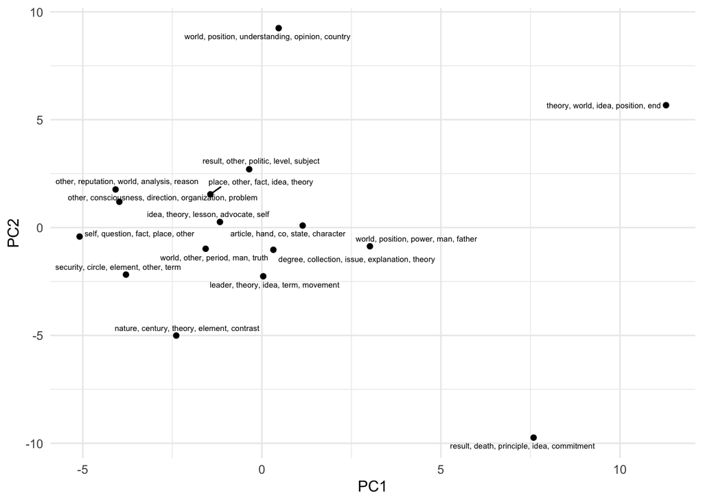

```r
library(ggrepel)

pca %>%
  ggplot(aes(PC1, PC2)) +
    geom_point() +
    geom_text_repel(aes(label=name), size=2)
```